# K Nearest Neighbors

Andrew Fogarty

1/20/2020

```r
# load python
library(reticulate)
use_python('C:/Users/Andrew/Anaconda3/')
library(knitr)
```

```python
# load packages
import pandas as pd
import numpy as np
import matplotlib.pyplot as plt
import time
import plotly.express as px
import seaborn as sns

from sklearn.neighbors import KNeighborsClassifier
from sklearn.metrics import confusion_matrix, classification_report, accuracy_score
from sklearn.datasets import fetch_openml, load_iris
from prettytable import PrettyTable

np.random.seed(0) # set seed
```

# 1 Introduction

The *K Nearest Neighbors (KNN)* algorithm is part of a family of *classifier* algorithms that aim to predict the *class* or *category* of an observation. KNN works by calculating the distance, often the Euclidean (i.e., straight line) distance, between observations. The algorithm predicts the class or category of an observation by comparing the closeness of the observation to *K* neighbors and then inferring that depending on the specified number of neighbors, the observation of interest then must be the same class as its nearest neighbor(s) because it shares a similar value. For instance, if `K = 1`, then the observation of interest will be classified as the same category as its nearest single `K = 1` data point. While relatively effective, KNN is rarely used by practitioners owing to its calculation costs as we shall see later. However, the underlying distance calculations and intuition behind KNN underlies many natural language processing (NLP) techniques which aim to run distance and clustering algorithms on words.

# 2 When to Use KNN

In short, KNN excels at classifying data that have some sort of clear demarcation between features. We will make this point clear in several examples before trying KNN on a more advanced data set. Let’s begin by looking at the iris data set from `sklearn`.

```python
# load iris from sklearn
iris = load_iris()

# create df
iris_df = pd.DataFrame(iris['data'], columns  =  iris.feature_names)
iris_df['label'] = iris.target # create dependent variable

# create masks to recode
setosa = iris_df['label'] == 0 # setosa
versicolor = iris_df['label'] == 1 # versicolor
virginica = iris_df['label'] == 2 # virginica

# apply mask
iris_df.loc[setosa, 'label'] = 'Setosa'
iris_df.loc[versicolor, 'label'] = 'Versicolor'
iris_df.loc[virginica, 'label'] = 'Virginica'

# create the default pairplot
cols = ['sepal length (cm)', 'sepal width (cm)', 'petal length (cm)', 'petal width (cm)']
sns.pairplot(iris_df, vars = cols,  hue = "label")
```

In the graph below, `seaborn` plots each iris feature against each other in a mixture of scatter and density plots. Drawing on the intuition described above, we can visually see that KNN would excel at classifying Setosas because it is in many cases separated from Virginicas and Versicolors. However, KNN would have some problems perfectly differentiating Virginicas and Versicolors, owing to the fact that their data points are close together. Again, this problem occurs because the classifier is calculating distances between points and then choosing the label of the point with the closest distance.

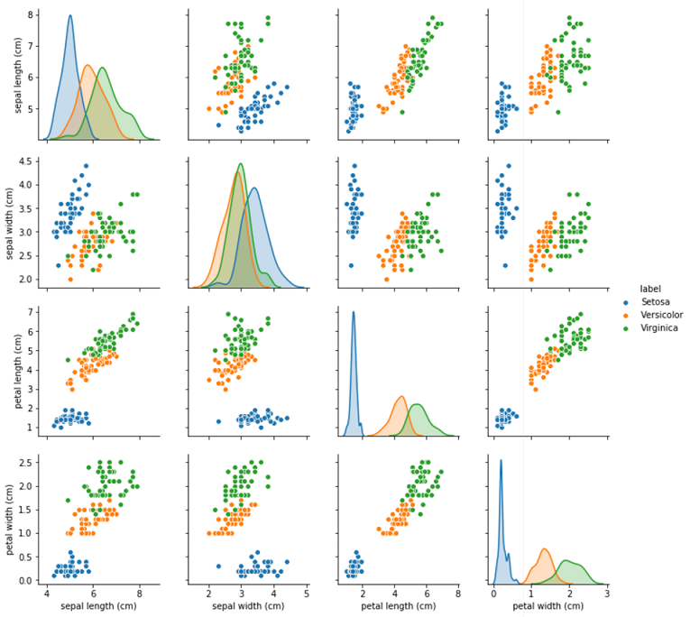

Visualizing the Data

To better understand the types of data distributions that KNN would excel at classifying, we begin by generating some artificial data. The first function generates our data in such a manner that it perfectly separates the data based on the threshold specified. The second function alters the data generated from the first by introducing some randomness into the labels. Instead of perfect separation, we now have some probability, that we can set, whereby close by observations can now have the opposite label, thereby making our algorithm’s classification task much harder.

```python
def gen_data(num_points):
    # make empty arrays
    x = np.zeros((num_points, 2))
    y = np.zeros((num_points, 1))

    # loop over length of arrays
    for i in range(len(x)):
        for j in range(2): # loop over number of features

            x[i][0] = np.random.uniform(0, 1) # generate data between [0, 1]
            x[i][1] = np.random.uniform(0, 1) # generate data between [0, 1]

        # set arbitrary comparison to generate y labels
        if x[i, 0] <= x[i, 1]:
            y[i] = 0
        else:
            y[i] = 1

    return ({'X': x, 'Y': y}) # return a dictionary


def mix_data(threshold1, threshold2):
    for i in range(len(X)):
        gen_random_value = np.random.random_sample()
        if all([X[i, 0] >= threshold1, X[i, 1] >= threshold2]):
            indx = i
            if gen_random_value > .5:
                Y[indx] = 1
            else:
                Y[indx] = 0
```

We generate data like so:

```python
data = gen_data(600)
X = data['X'] # 600 observations; 2 features
Y = data['Y'] # 600 labels
Y = Y.ravel() # reshape (600,) for classifier use
```

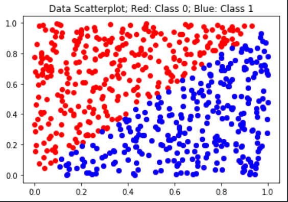

Visualizing the Data

With our data generated, we can now create our own KNN classifier so that we can better understand what exactly `sklearn` is doing when we use its classifier. To create our own KNN classifier, we need to create the classifier and a function that calculates the Euclidean distance between points. We begin with Euclidean distance:

```python
def EuclideanDistance(v1, v2):
    # calculates the distance between two points
    sum = 0.0
    for index in range(len(v1)): # loop over length of container
        sum += (v1[index] - v2[index]) ** 2 # square for positive
    return sum ** 0.5 # square root to undo
```